# EDA dla azjatyckich tekstów religijnych

Dane pochodzą z projektu "Project Gutenberg", lecz zostały wcześniej przetworzone. Czyszczenie danych przeprowadzili **PREETI SAH i ERNEST FOKOUE w (2019) "WHAT DO ASIAN RELIGIONS HAVE IN COMMON? AN UNSUPERVISED TEXT ANALYTICS EXPLORATION"**. Analiza tekstu może nam odpowiedzieć na to jak podobne są do siebie te treści, a z drugiej strony jak specyficznego języka mogą używać różne kultury. Ciekawe czy uda się za pomocą metod uczenia bez nadzoru przyporządkować korpusy do pozycji literackich, z których pochodzą. Zbiór korpusów pochodzi z 8 tekstów.

1.Hinduism (India): Yogasutras, Upanishads  
2.Buddhism (Tibet): Four Noble Truth of Buddhism  
3.Taoism (China): Tao Te Ching  
4.Christianity (Central Asia/America): Book of Proverb, Book of Ecclesiastes, Book of Ec-clesiasticus, Book of Wisdom

```python
import pandas as pd
import numpy as np
import matplotlib.pyplot as plt
import seaborn as sns
import scipy
import scipy.stats
import sklearn
```

```python
df=pd.read_csv("C:\\Users\\huber\\Dropbox\\PW\\2 SEMESTR\\Wstep do uczenia maszynowego\\AllBooks_baseline_DTM_Unlabelled.csv")
#df = pd.read_csv("C:\\Users\\Lenovo\\Desktop\\Wstęp do uczenia maszynowego\\Dane\\AllBooks_baseline_DTM_Unlabelled.csv")
```

```python
df.head()
```

|  | # foolishness | hath | wholesome | takest | feelings | anger | vaivaswata | matrix | kindled | convict | ... | erred | thinkest | modern | reigned | sparingly | visual | thoughts | illumines | attire | explains |
| --- | --- | --- | --- | --- | --- | --- | --- | --- | --- | --- | --- | --- | --- | --- | --- | --- | --- | --- | --- | --- | --- |
| 0 | 0.0 | 0.0 | 0.0 | 0.0 | 0.0 | 0.0 | 0.0 | 0.0 | 0.0 | 0.0 | ... | 0.0 | 0.0 | 0.0 | 0.0 | 0.0 | 0.0 | 0.0 | 0.0 | 0.0 | 0.0 |
| 1 | 0.0 | 0.0 | 0.0 | 0.0 | 0.0 | 0.0 | 0.0 | 0.0 | 0.0 | 0.0 | ... | 0.0 | 0.0 | 0.0 | 0.0 | 0.0 | 0.0 | 0.0 | 0.0 | 0.0 | 0.0 |
| 2 | 0.0 | 0.0 | 0.0 | 0.0 | 0.0 | 0.0 | 0.0 | 0.0 | 0.0 | 0.0 | ... | 0.0 | 0.0 | 0.0 | 0.0 | 0.0 | 0.0 | 0.0 | 0.0 | 0.0 | 0.0 |
| 3 | 0.0 | 0.0 | 0.0 | 0.0 | 0.0 | 0.0 | 0.0 | 0.0 | 0.0 | 0.0 | ... | 0.0 | 0.0 | 0.0 | 0.0 | 0.0 | 0.0 | 0.0 | 0.0 | 0.0 | 0.0 |
| 4 | 0.0 | 0.0 | 0.0 | 0.0 | 0.0 | 0.0 | 0.0 | 0.0 | 0.0 | 0.0 | ... | 0.0 | 0.0 | 0.0 | 0.0 | 0.0 | 0.0 | 0.0 | 0.0 | 0.0 | 0.0 |

5 rows × 8266 columns

```python
df.info()
```

```
<class 'pandas.core.frame.DataFrame'>
RangeIndex: 590 entries, 0 to 589
Columns: 8266 entries, # foolishness to explains
dtypes: float64(8266)
memory usage: 37.2 MB
```

```python
df.describe()
```

|  | # foolishness | hath | wholesome | takest | feelings | anger | vaivaswata | matrix | kindled | convict | ... | erred | thinkest | modern | reigned | sparingly | visual | thoughts | illumines | attire | explains |
| --- | --- | --- | --- | --- | --- | --- | --- | --- | --- | --- | --- | --- | --- | --- | --- | --- | --- | --- | --- | --- | --- |
| count | 590.000000 | 590.000000 | 590.000000 | 590.000000 | 590.000000 | 590.000000 | 590.000000 | 590.000000 | 590.000000 | 590.000000 | ... | 590.000000 | 590.000000 | 590.000000 | 590.000000 | 590.000000 | 590.000000 | 590.000000 | 590.000000 | 590.000000 | 590.000000 |
| mean | 0.003390 | 0.566102 | 0.006780 | 0.001695 | 0.032203 | 0.059322 | 0.001695 | 0.001695 | 0.006780 | 0.001695 | ... | 0.003390 | 0.006780 | 0.003390 | 0.001695 | 0.001695 | 0.001695 | 0.079661 | 0.008475 | 0.005085 | 0.003390 |
| std | 0.058173 | 1.777487 | 0.082129 | 0.041169 | 0.488211 | 0.326851 | 0.041169 | 0.041169 | 0.082129 | 0.041169 | ... | 0.058173 | 0.100701 | 0.058173 | 0.041169 | 0.041169 | 0.041169 | 0.366824 | 0.091744 | 0.071186 | 0.058173 |
| min | 0.000000 | 0.000000 | 0.000000 | 0.000000 | 0.000000 | 0.000000 | 0.000000 | 0.000000 | 0.000000 | 0.000000 | ... | 0.000000 | 0.000000 | 0.000000 | 0.000000 | 0.000000 | 0.000000 | 0.000000 | 0.000000 | 0.000000 | 0.000000 |
| 25% | 0.000000 | 0.000000 | 0.000000 | 0.000000 | 0.000000 | 0.000000 | 0.000000 | 0.000000 | 0.000000 | 0.000000 | ... | 0.000000 | 0.000000 | 0.000000 | 0.000000 | 0.000000 | 0.000000 | 0.000000 | 0.000000 | 0.000000 | 0.000000 |
| 50% | 0.000000 | 0.000000 | 0.000000 | 0.000000 | 0.000000 | 0.000000 | 0.000000 | 0.000000 | 0.000000 | 0.000000 | ... | 0.000000 | 0.000000 | 0.000000 | 0.000000 | 0.000000 | 0.000000 | 0.000000 | 0.000000 | 0.000000 | 0.000000 |
| 75% | 0.000000 | 0.000000 | 0.000000 | 0.000000 | 0.000000 | 0.000000 | 0.000000 | 0.000000 | 0.000000 | 0.000000 | ... | 0.000000 | 0.000000 | 0.000000 | 0.000000 | 0.000000 | 0.000000 | 0.000000 | 0.000000 | 0.000000 | 0.000000 |
| max | 1.000000 | 14.000000 | 1.000000 | 1.000000 | 11.000000 | 4.000000 | 1.000000 | 1.000000 | 1.000000 | 1.000000 | ... | 1.000000 | 2.000000 | 1.000000 | 1.000000 | 1.000000 | 1.000000 | 5.000000 | 1.000000 | 1.000000 | 1.000000 |

8 rows × 8266 columns

Można zauważyć, że mamy tutaj problem przekleństwa wymiarowości. Mamy do czynienia z macierzą o wymiarach 590 na 8266, na dodatek jest to macierz rzadka, to jest pełna zer. Kolumny stanowią indykatory zliczające wystąpienie danego słowa w korpusie. Każdy jeden fragment korpusu jest obserwacją. Zobaczmy czy jakieś charakterystyczne słowa występują najczęściej w tych tekstach.

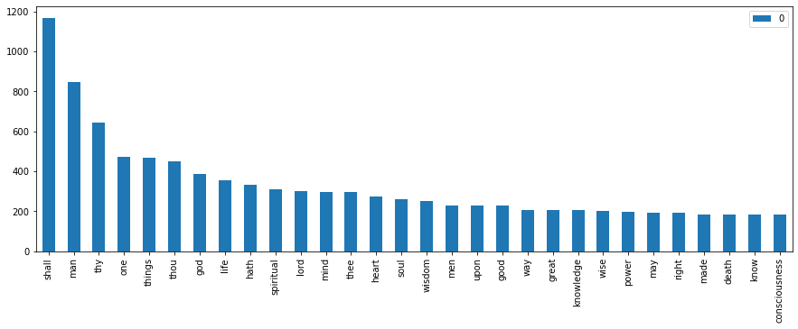

```python
Names=pd.DataFrame(df.sum(axis=0))
#Names.index.name = 'newhead'
#Names.reset_index(inplace=True)
#Names.sort_values(by=0, ascending=False).iloc[0:30,]
#Names.columns=["Name", "Times"]
Names.sort_values(by=0, ascending=False).iloc[0:30,].plot(kind="bar", figsize=(15,5))
plt.show()
```

Jak widzimy niektóre pojawiają się naprawdę często, nie są one jednak na pierwszy rzut oka charakterystyczne dla jakichkolwiek tekstów. Może być jednak tak, że okaże się zupełnie co innego, bo tylko część z ksiąg będzie używała składni do której będą wymagane niektóre z tych słów. Przyjrzyjmy się z kolei tym rzadziej występującym słowom, będziemy tutaj szukać czy da się tutaj jakoś zmniejszyć wymiar naszych danych przez usunięcie słów, które występują bardzo rzadko albo w ogóle.

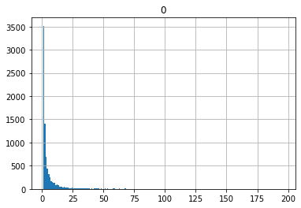

```python
Names[Names<200].hist(bins=200)
plt.show()
```

```python
Names.describe()
```

|  | 0 |
| --- | --- |
| count | 8266.000000 |
| mean | 7.332325 |
| std | 27.331082 |
| min | 1.000000 |
| 25% | 1.000000 |
| 50% | 2.000000 |
| 75% | 5.000000 |
| max | 1168.000000 |

Jest bardzo dużo słów, które rzadko występują, ponad 50% z nich występuje 2 razy lub rzadziej. Takie kolumny będą dobrymi kandydatami do usunięcia, gdyż nie powinny wnosić nam dużo do modelu.

Sprawdźmy teraz jak mają się do siebie sumy użytych słów w poszczególnych księgach. Chcielibyśmy aby były one mniej więcej podobne, gdyż w przypadku dużych różnic w długościach algorytmy klasteryzacji mogą uznawać po prostu długie książki za podobne do siebie, mimo tego, że byłyby zupełnie inne.

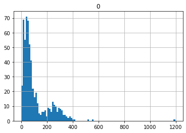

```python
Books=pd.DataFrame(df.sum(axis=1))
#Names1.sort_values(by=0, ascending=False)[1:50]
Books.hist(bins=100)
plt.show()
```

Książki różnią się ilością zawieranych słów, jednak znaczna większość jest w przedziale 0-200. Powyżej 400 słów jest bardzo niewiele obserwacji.

### Orginalny plik tekstowy

Pozwoliliśmy sobie na rzucenie okiem także na orginalny plik tekstowy, w następnych krokach rysujemy ładnie wyglądającą mapę wyrazów najczęściej się pojawiających i przykładamy do owego tekstu dwa narzędzia rodem z NLP to jest wskaźnik *subjectivity* i *polarity*.

```python
TT = open('C:\\Users\\huber\\Dropbox\\PW\\2 SEMESTR\\Wstep do uczenia maszynowego\\Complete_data.txt', 'r')
TXT = TT.read()
TT.close()
```

```python
import re
DF = re.split('\d+\.\d+', TXT)
DF1=pd.DataFrame(DF).iloc[1:592, ]
DF1=DF1.rename(columns={0:"txt"})
DF1
```

|  | txt |
| --- | --- |
| 1 | \n§ 1.The Buddha: "What do you think, Rahula:... |
| 2 | \n§ 2.Once the Blessed One was staying at Kos... |
| 3 | \n§ 3."'Stress should be known. The cause by ... |
| 4 | \n§ 4."Vision arose, clear knowing arose, dis... |
| 5 | \n§ 5.Sariputta: "There are these three forms... |
| ... | ... |
| 587 | \n 14:1. Again, another designing to sail, and... |
| 588 | \ncondemning both the makers and the worshippe... |
| 589 | \nworthily punished, and were destroyed by a m... |
| 590 | \n 17:1. For thy judgments, O Lord, are great,... |
| 591 | \nintercession, in the sedition on occasion of... |

591 rows × 1 columns

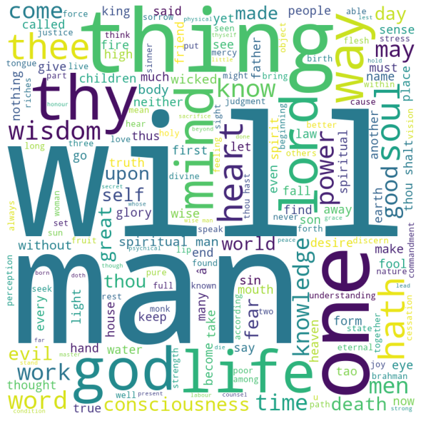

```python
from wordcloud import WordCloud, STOPWORDS
comment_words = ''
stopwords = set(STOPWORDS)
for val in DF:

    # typecaste each val to string
    val = str(val)

    # split the value
    tokens = val.split()

    # Converts each token into lowercase
    for i in range(len(tokens)):
        tokens[i] = tokens[i].lower()

    comment_words += " ".join(tokens)+" "

wordcloud = WordCloud(width = 800, height = 800,
                background_color ='white',
                stopwords = stopwords,
                min_font_size = 10).generate(comment_words)

# plot the WordCloud image
plt.figure(figsize = (8, 8), facecolor = None)
plt.imshow(wordcloud)
plt.axis("off")
plt.tight_layout(pad = 0)

plt.show()
```

Mapa słów najczęściej się pojawiających tym większą czcionkę stosuje im słowo częściej wystepowało w całym korpusie. Na tekst nałożony jest filtr w postaci słownika STOPWORDS, który usuwa wyrazy potencjalnie nie niosące treści. Mając na uwadzę ten fakt możemy też porównać, które słowa zostały uznane przez autorów bazy danych za warte uwzględnienia, a które pominięte (np. "Will" i "Shall").

```python
#!pip install textblob
from textblob import TextBlob
DF1['polarity']=DF1.loc[:,'txt'].apply(lambda x:TextBlob(x).sentiment.polarity)
DF1['subjectivity']=DF1.loc[:,'txt'].apply(lambda x:TextBlob(x).sentiment.subjectivity)
DF1
```

|  | txt | polarity | subjectivity |
| --- | --- | --- | --- |
| 1 | \n§ 1.The Buddha: "What do you think, Rahula:... | -0.059836 | 0.395902 |
| 2 | \n§ 2.Once the Blessed One was staying at Kos... | 0.117647 | 0.477941 |
| 3 | \n§ 3."'Stress should be known. The cause by ... | 0.180979 | 0.547078 |
| 4 | \n§ 4."Vision arose, clear knowing arose, dis... | 0.343080 | 0.664732 |
| 5 | \n§ 5.Sariputta: "There are these three forms... | 0.000000 | 0.000000 |
| ... | ... | ... | ... |
| 587 | \n 14:1. Again, another designing to sail, and... | 0.197806 | 0.568295 |
| 588 | \ncondemning both the makers and the worshippe... | 0.010802 | 0.569444 |
| 589 | \nworthily punished, and were destroyed by a m... | 0.133667 | 0.569179 |
| 590 | \n 17:1. For thy judgments, O Lord, are great,... | -0.076437 | 0.650194 |
| 591 | \nintercession, in the sedition on occasion of... | 0.042108 | 0.597840 |

591 rows × 3 columns

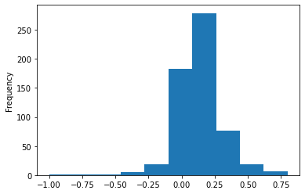

```python
DF1['polarity'].plot(kind = 'hist')
plt.show()
```

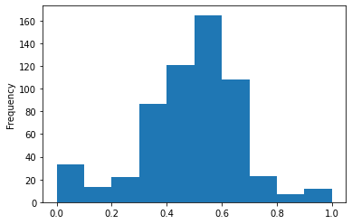

```python
DF1['subjectivity'].plot(kind = 'hist')
plt.show()
```

Z perspektywy oceny eksperckiej językoznawców teksty uznane zostałyby za bardziej nacechowane pozytywnie, zaś ich subiektywność w dużej częsci za pomiędzy faktem a opinią.

Na zakończenie poczytajmy sobie w celach weryfikacji naszych intuicji teksty o skrajnych wartościach obu współczynników. Niech to będzie nasze słowo na wtorek!

```python
list(DF1.sort_values(by="polarity", ascending=True).iloc[0:3,0])
```

[output not shown]

```python
list(DF1.sort_values(by="polarity", ascending=False).iloc[0:3,0])
```

```
['\n Beyond the senses are the objects, beyond the objects is the mind, beyond the mind is the intellect, beyond the intellect is the great Atman.   \n',
 '\n The intelligent man, who has heard and repeated the ancient story of Nachiketas, told by the Ruler of Death, is glorified in the world of Brahman.   \n',
 '\n By the worship of the Unmanifested one end is attained; by the worship of the manifested, another.  Thus we have heard from the wise men who taught us this.   \n']
```

```python
list(DF1.sort_values(by="subjectivity", ascending=True).iloc[0:3,0])
```

```
['\n No mortal lives by the in-coming breath (Prana) or by the out-going breath (Apana), but he lives by another on which these two depend.   \n',
 '\n This Word is indeed Brahman.  This Word is indeed the Supreme. He who knows this Word obtains whatever he desires.   \n',
 '\n He ran towards it and He (Brahman) said to him: "Who art thou?" "I am Agni, I am Jataveda," he (the Fire-god) replied.   \n']
```

```python
list(DF1.sort_values(by="subjectivity", ascending=False).iloc[0:3,0])
```

```
['\n They said to Fire: "O Jataveda (All-knowing)!  Find out what mysterious spirit this is."  He said: "Yes."   \n',
 '\n Yama said: O Brahmana!  Revered guest!  My salutations to thee. As thou hast remained three nights in my house without food, therefore choose three boons, O Brahmana.   \n',
 '\n The Brahman perceived this and appeared before them.  They did not know what mysterious form it was.   \n']
```